# Lab 7 – Sampling Distribution and CLT

2024-10-18

## Introduction

Run this line. This will do three things:

- Load necessary packages and datasets
- Creates the `gh()` function, a very convenient shortcut for creating histograms
- Source R code from a URL; this will contain the functions we will use. When you run this, you should see the functions now in your environment

```r
library(ggplot2)
library(dplyr)

theme_set(theme_bw())

college <- read.csv("https://collinn.github.io/data/college2019.csv")

## Better histograms
gh <- function(bins = 8) {
  geom_histogram(color = 'black', fill = 'gray80', bins = bins)
}

## Source functions
source("https://collinn.github.io/f24/labs/clt_lab_functions.R")
```

For an illustration of how `gh()` is used, see:

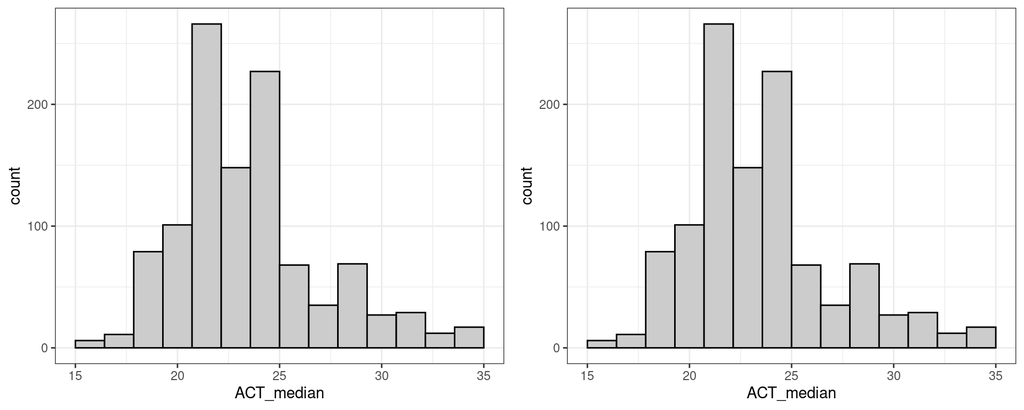

```r
## Default way
p1 <- ggplot(college, aes(ACT_median)) +
  geom_histogram(color = 'black', fill = 'gray80', bins = 15)

## Superior awesome gh() way
p2 <- ggplot(college, aes(ACT_median)) + gh(bins = 15)

## They are identical
gridExtra::grid.arrange(p1, p2, nrow = 1)
```

## Sampling Distribution and CLT

### `sampleNormalData()`

Here, we introduce the `sampleNormalData()` function. This function takes 3 arguments:

- `n` The number of observations we want in our sample
- `mu` The true population mean
- `sig` The true population standard deviation

This function works by

1. Drawing `n` observations from a normal distribution with mean `mu` and standard deviation `sig`
2. Taking the mean value ($\overline{x}$) from this sample
3. Repeating this process 1000 times

It will return a data.frame where each row contains the sample number and the mean value. It will be important to note: this dataset makes up a *distribution* of $\overline{x}$ in the sense that this is what it would look like *if we could* create a sample repeatedly and find each value of $\overline{x}$.

```r
df <- sampleNormalData(n = 15, mu = 100, sig = 15, samples = 1000)

## Example of first 10 rows
head(df, 10)
```

```
##       xbar sample
## 1   99.952      1
## 2  104.601      2
## 3   99.632      3
## 4   98.150      4
## 5  102.565      5
## 6   97.524      6
## 7  101.808      7
## 8  104.354      8
## 9   96.213      9
## 10 100.061     10
```

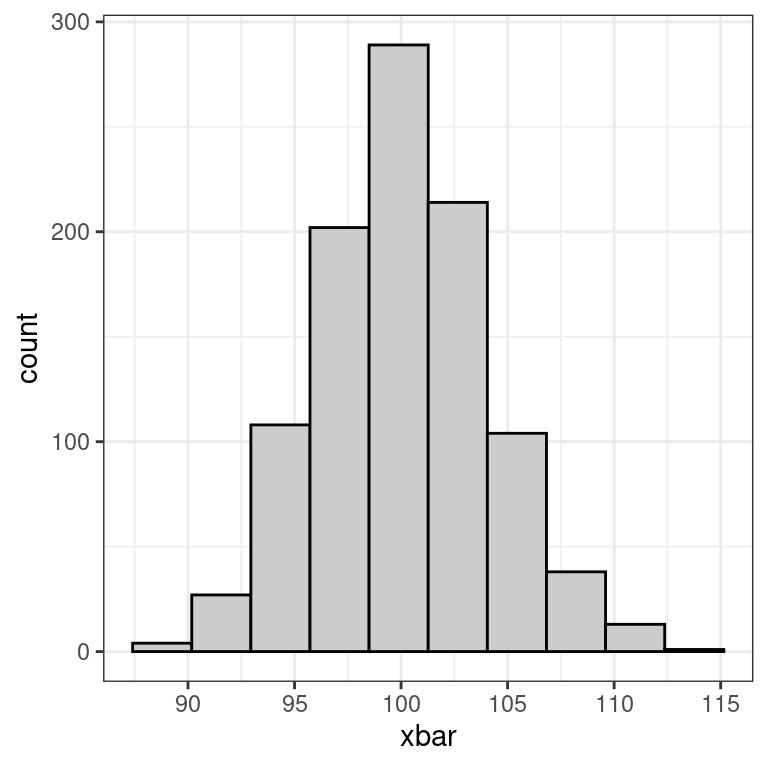

```r
## Plot distribution of xbar with gh()
ggplot(df, aes(xbar)) + gh(bins = 10)
```

### `getSampleMean()`

Here, we introduce the `getSampleMean()` function. This function takes 3 arguments:

- `data` The dataset we wish to sample
- `variable` The name of the variable we want to sample
- `n` The number of observations we want in each sample

This function work similar to `sampleNormalData()` in that `n` tells us the sample size. However, instead of sampling from a normal distribution, we provide two other arguments: `data` tells us which dataset we wish to use and `variable` tells us which variable we want to sample and create a sample mean for.

For example, the following code collections 1000 samples from the variable `FourYearComp_Males`, each with 20 observations. It then returns a data.frame where each row includes the sample number as well as the mean for that sample

```r
## Sample from the variable FourYearComp_Males
df_males <- getSampleMean(college, FourYearComp_Males, n = 20)

## Example of first 10 rows
head(df_males, 10)
```

```
##       xbar sample
## 1  0.47904      1
## 2  0.48849      2
## 3  0.46714      3
## 4  0.45684      4
## 5  0.48785      5
## 6  0.48852      6
## 7  0.43937      7
## 8  0.49809      8
## 9  0.52052      9
## 10 0.50882     10
```

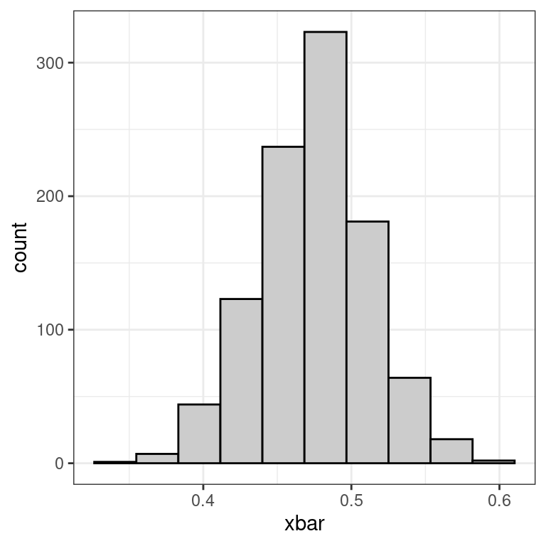

```r
## Plot distribution of xbar with gh()
ggplot(df_males, aes(xbar)) + gh(bins = 10)
```

### `simulateConfInt()`

Here, we introduce the `simulateConfInt()` function. This function takes 3 arguments:

- `n` Number of observations in sample
- `m` Multiplier for standard error (i.e., do we want our CI to be $\pm$ 2 standard error)
- `sd` The population standard deviation

The function works by simulating the construction of 25 confidence intervals. The value `n` will determine the number of observations in our sample. The value for `m` determines the range of our confidence interval, as in the equation

$$\overline{x} \pm m \times s$$
where $s$ is the standard error (i.e., $s = \sigma / \sqrt{n}$). Finally, `sd` determines the standard deviation from the population.

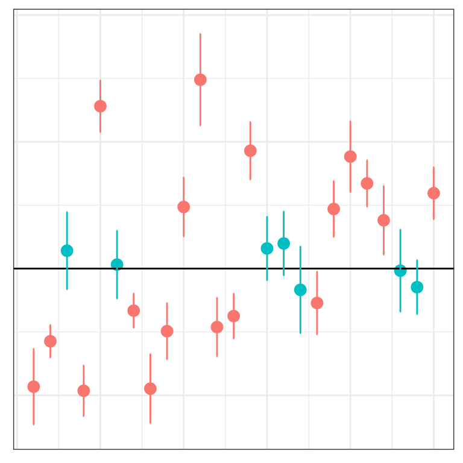

```r
simulateConfInt(n = 15, m = 0.5, sd = 50)
```

Although it will not be necessary, I will provide this illustration again here for reference. We can think of the $m$ term as being $m = 0, 1, 2, 3$ below (i.e., $\mu \pm m \times \sigma$) to give context for where these values should lie.

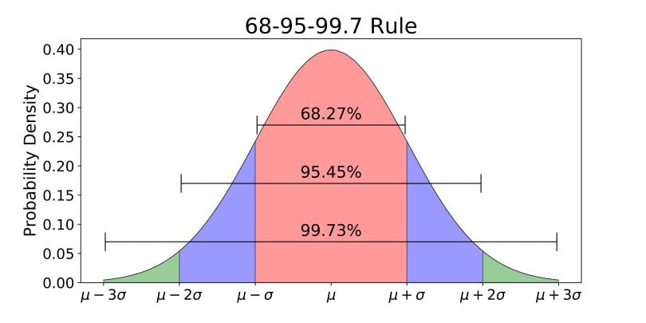